# Sequence Divergence vs Differential Expression in the Inv4m Introgression

Fausto Rodriguez

March 23, 2026

# Overview

Are the expression differences between Inv4m and B73 haplotypes explained by per-gene CDS sequence divergence, or do some genes show excess DE beyond what divergence predicts?

We use LAST alignments (B73 vs Mi21 CDS) already computed by the jcvi ortholog pipeline. Only genes within the shared introgression on chromosome 4 are analyzed.

```r
library(here)
library(tidyverse)
library(ggrepel)
library(GenomicRanges)
library(MASS)      # rlm (robust regression)
library(quantreg)  # rq  (quantile regression)
library(evd)       # GPD fitting for extreme value analysis
library(ggtext)    # richtext labels
library(ggbeeswarm) # beeswarm plots
library(ggfx)      # shadow effects

source(here("scripts", "utils", "setup_paths.R"))
paths <- setup_project_paths("inversion_paper")
```

# Load data

## LAST alignments (CDS percent identity)

```r
last_file <- "/Users/fvrodriguez/mnt/rrellan/DOE_CAREER/inv4m/nilhifimi21/microsynteny/B73.Mi21.last"

last_cols <- c("query", "subject", "pct_identity", "aln_len", "mismatches",
               "gaps", "qstart", "qend", "sstart", "send", "evalue", "score")

last_raw <- read.table(last_file, header = FALSE, sep = "\t",
                       col.names = last_cols, comment.char = "#")

# Strip transcript suffix to get gene IDs
last_raw <- last_raw %>%
  mutate(
    b73_gene = sub("_T\\d+$", "", query),
    mi21_gene = sub("^Mi21_", "", sub("_T\\d+$", "", subject))
  )

cat("Raw LAST alignments:", nrow(last_raw), "\n")
```

```
## Raw LAST alignments: 1816628
```

## DEG results

```r
degs <- read.csv(file.path(paths$intermediate, "deg_both_models_genotype.csv"))
cat("DEG results:", nrow(degs), "genes\n")
```

```
## DEG results: 465 genes
```

## Gene coordinates (B73 v5 GFF)

```r
v5_gff_file <- file.path(paths$data, "Zea_mays.Zm-B73-REFERENCE-NAM-5.0.59.chr.gff3")
genes_gr <- rtracklayer::import(v5_gff_file)
genes_gr <- genes_gr[genes_gr$type == "gene" &
                     as.character(seqnames(genes_gr)) %in% as.character(1:10)]
genes <- as.data.frame(genes_gr)
genes$ID <- gsub("gene:", "", genes$ID)
```

# Define regions and filter

```r
# Boundaries
introgression_start <- 157012149
introgression_end   <- 195900523
inv4m_start <- genes$start[genes$ID == "Zm00001eb190470"]
inv4m_end   <- genes$end[genes$ID == "Zm00001eb194800"]

# Chr4 introgression genes
introgression_genes <- genes %>%
  filter(seqnames == 4, start >= introgression_start, end <= introgression_end) %>%
  mutate(location = ifelse(start >= inv4m_start & end <= inv4m_end,
                           "Inv4m", "flanking"))

cat("Introgression genes:", nrow(introgression_genes), "\n")
```

```
## Introgression genes: 1099
```

```r
cat("  Inv4m:", sum(introgression_genes$location == "Inv4m"), "\n")
```

```
##   Inv4m: 434
```

```r
cat("  CTRL:", sum(introgression_genes$location == "flanking"), "\n")
```

```
##   CTRL: 665
```

# Best LAST hit per gene in introgression

Keep the highest-scoring ortholog alignment for each B73 gene within the introgression.

```r
best_hits <- last_raw %>%
  filter(b73_gene %in% introgression_genes$ID) %>%
  # Keep only self-ortholog hits (same gene ID in B73 and Mi21)
  filter(b73_gene == mi21_gene) %>%
  group_by(b73_gene) %>%
  slice_max(score, n = 1, with_ties = FALSE) %>%
  ungroup() %>%
  dplyr::select(gene = b73_gene, pct_identity, aln_len, score)

cat("Genes with ortholog hits:", nrow(best_hits), "\n")
```

```
## Genes with ortholog hits: 902
```

```r
cat("Identity range:", round(min(best_hits$pct_identity), 2), "-",
    round(max(best_hits$pct_identity), 2), "%\n")
```

```
## Identity range: 84.07 - 100 %
```

# Merge datasets

```r
# Load master locus labels
locus_labels <- read.csv(file.path(paths$data, "locus_labels_master.csv")) %>%
  dplyr::select(gene, locus_label)

merged <- best_hits %>%
  inner_join(degs, by = "gene") %>%
  inner_join(
    introgression_genes %>% dplyr::select(ID, location, start),
    by = c("gene" = "ID")
  ) %>%
  left_join(locus_labels, by = "gene") %>%
  mutate(
    cds_divergence = 100 - pct_identity,
    abs_logFC = abs(logFC),
    direction = ifelse(logFC > 0, "Up in Inv4m", "Down in Inv4m"),
    display_label = coalesce(locus_label, gene)
  )

cat("Merged dataset:", nrow(merged), "genes\n")
```

```
## Merged dataset: 254 genes
```

```r
cat("  DEGs (FDR < 0.05):", sum(merged$adj.P.Val < 0.05), "\n")
```

```
##   DEGs (FDR < 0.05): 254
```

```r
cat("  Up:", sum(merged$direction == "Up in Inv4m"),
    " Down:", sum(merged$direction == "Down in Inv4m"), "\n")
```

```
##   Up: 114  Down: 140
```

# Analysis

## Model selection

```r
fit_null <- lm(abs_logFC ~ 1, data = merged)
fit_div  <- lm(abs_logFC ~ cds_divergence, data = merged)
fit_loc  <- lm(abs_logFC ~ location, data = merged)
fit_add  <- lm(abs_logFC ~ cds_divergence + location, data = merged)
fit_int  <- lm(abs_logFC ~ cds_divergence * location, data = merged)

models <- list(null = fit_null, divergence = fit_div, location = fit_loc,
               additive = fit_add, interaction = fit_int)

data.frame(
  model = names(models),
  df = sapply(models, function(m) length(coef(m))),
  AIC = round(sapply(models, AIC), 1),
  BIC = round(sapply(models, BIC), 1),
  adj_R2 = round(sapply(models, function(m) summary(m)$adj.r.squared), 4)
) %>% arrange(BIC)
```

|  | model | df | AIC | BIC | adj_R2 |
| --- | --- | --- | --- | --- | --- |
| additive | additive | 3 | 1032.2 | 1046.3 | 0.1037 |
| divergence | divergence | 2 | 1039.6 | 1050.2 | 0.0734 |
| interaction | interaction | 4 | 1033.2 | 1050.9 | 0.1035 |
| location | location | 2 | 1052.8 | 1063.4 | 0.0242 |
| null | null | 1 | 1058.0 | 1065.1 | 0.0000 |

```r
cat("=== Additive model ===\n")
```

```
## === Additive model ===
```

```r
summary(fit_add)
```

```
##
## Call:
## lm(formula = abs_logFC ~ cds_divergence + location, data = merged)
##
## Residuals:
##     Min      1Q  Median      3Q     Max
## -3.0515 -1.1299 -0.6354  0.5390  8.0448
##
## Coefficients:
##                Estimate Std. Error t value Pr(>|t|)
## (Intercept)     1.74532    0.17704   9.858  < 2e-16 ***
## cds_divergence  0.33273    0.06887   4.831 2.36e-06 ***
## locationInv4m  -0.71719    0.23264  -3.083  0.00228 **
## ---
## Signif. codes:  0 '***' 0.001 '**' 0.01 '*' 0.05 '.' 0.1 ' ' 1
##
## Residual standard error: 1.828 on 251 degrees of freedom
## Multiple R-squared:  0.1108, Adjusted R-squared:  0.1037
## F-statistic: 15.63 on 2 and 251 DF,  p-value: 4.002e-07
```

```r
cat("\n=== Interaction model ===\n")
```

```
##
## === Interaction model ===
```

```r
summary(fit_int)
```

```
##
## Call:
## lm(formula = abs_logFC ~ cds_divergence * location, data = merged)
##
## Residuals:
##     Min      1Q  Median      3Q     Max
## -2.8392 -1.1091 -0.6770  0.5359  8.0737
##
## Coefficients:
##                              Estimate Std. Error t value Pr(>|t|)
## (Intercept)                   1.68515    0.18754   8.986   <2e-16 ***
## cds_divergence                0.37737    0.08275   4.560    8e-06 ***
## locationInv4m                -0.50208    0.32089  -1.565    0.119
## cds_divergence:locationInv4m -0.14532    0.14930  -0.973    0.331
## ---
## Signif. codes:  0 '***' 0.001 '**' 0.01 '*' 0.05 '.' 0.1 ' ' 1
##
## Residual standard error: 1.828 on 250 degrees of freedom
## Multiple R-squared:  0.1141, Adjusted R-squared:  0.1035
## F-statistic: 10.73 on 3 and 250 DF,  p-value: 1.164e-06
```

```r
anova(fit_add, fit_int)
```

|  | Res.Df | RSS | Df | Sum of Sq | F | Pr(>F) |
| --- | --- | --- | --- | --- | --- | --- |
| 1 | 251 | 838.5358 | NA | NA | NA | NA |
| 2 | 250 | 835.3702 | 1 | 3.165678 | 0.9473877 | 0.3313259 |

```r
cat("\n=== ANOVA: location-only vs additive ===\n")
```

```
##
## === ANOVA: location-only vs additive ===
```

```r
anova(fit_loc, fit_add)
```

|  | Res.Df | RSS | Df | Sum of Sq | F | Pr(>F) |
| --- | --- | --- | --- | --- | --- | --- |
| 1 | 252 | 916.5161 | NA | NA | NA | NA |
| 2 | 251 | 838.5358 | 1 | 77.98024 | 23.34192 | 2.362125e-06 |

## Scatter: |log2FC| vs CDS divergence

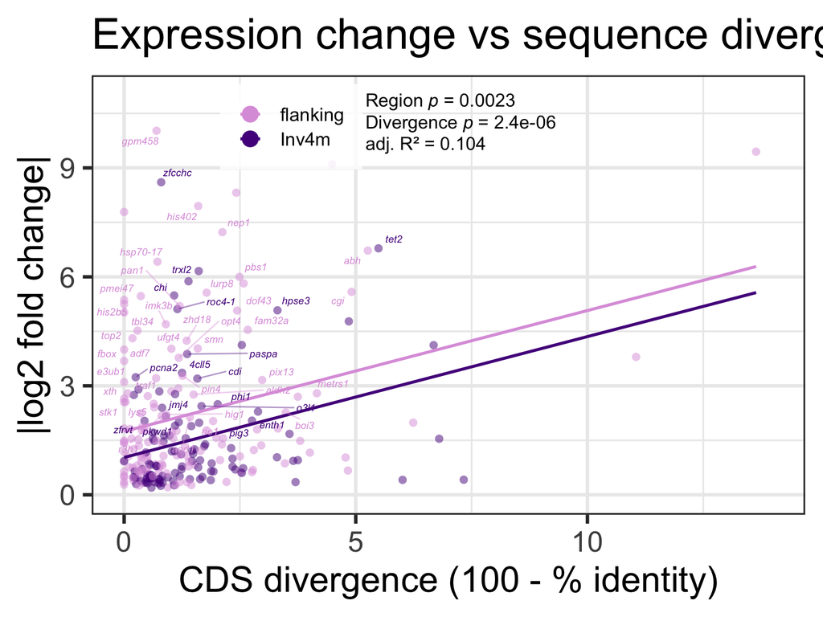

```r
# Use additive model for ANCOVA lines
fit_ancova <- fit_add

# Predicted ANCOVA lines
ancova_pred <- expand.grid(
  cds_divergence = seq(0, max(merged$cds_divergence), length.out = 200),
  location = c("Inv4m", "flanking")
)
ancova_pred$abs_logFC <- predict(fit_ancova, newdata = ancova_pred)

# Residuals for outlier labeling
merged$residual <- residuals(fit_ancova)

# Top outliers by residual magnitude
top_outliers <- merged %>%
  filter(abs(residual) > quantile(abs(residual), 0.95) | abs_logFC > 2) %>%
  mutate(
    fontface = ifelse(grepl("^jmj3$", display_label, ignore.case = TRUE),
                      "bold.italic", "italic")
  )

# Extract stats for annotation
ancova_sum <- summary(fit_ancova)
ancova_coefs <- coef(ancova_sum)
r2 <- round(ancova_sum$adj.r.squared, 3)
p_div <- ancova_coefs["cds_divergence", "Pr(>|t|)"]
p_loc <- ancova_coefs["locationInv4m", "Pr(>|t|)"]

x_max <- ceiling(max(merged$cds_divergence))
y_max <- ceiling(max(merged$abs_logFC))

# Stats annotation (ggtext richtext for italic p)
stat_label <- paste0(
  "Region *p* = ", format(p_loc, digits = 2), "<br>",
  "Divergence *p* = ", format(p_div, digits = 2), "<br>",
  "adj. R\u00B2 = ", r2
)

p_scatter <- ggplot(merged, aes(x = cds_divergence, y = abs_logFC,
                                 color = location)) +
  geom_point(aes(shape = adj.P.Val < 0.05), size = 2, alpha = 0.5) +
  geom_line(data = ancova_pred, linewidth = 1) +
  geom_text_repel(
    data = top_outliers,
    aes(label = display_label, fontface = fontface),
    size = 2.5, max.overlaps = 15, segment.alpha = 0.4,
    show.legend = FALSE
  ) +
  coord_cartesian(xlim = c(0, x_max), ylim = c(0, y_max)) +
  scale_color_manual(
    values = c("Inv4m" = "purple4", "flanking" = "plum")
  ) +
  scale_shape_manual(values = c("TRUE" = 16, "FALSE" = 1), guide = "none") +
  geom_richtext(
    data = data.frame(x = 5.1, y = 11.2),
    aes(x = x, y = y), label = stat_label,
    inherit.aes = FALSE, hjust = 0, vjust = 1,
    size = 4.5, label.colour = NA, fill = NA
  ) +
  labs(
    x = "CDS divergence (100 - % identity)",
    y = "|log2 fold change|",
    title = "Expression change vs sequence divergence in the Inv4m introgression"
  ) +
  guides(color = guide_legend(override.aes = list(size = 4, alpha = 1))) +
  theme_bw(base_size = 25) +
  theme(
    legend.position = c(0.18, 0.98),
    legend.justification = c(0, 1),
    legend.title = element_blank(),
    legend.text = element_text(size = 13),
    legend.key.size = unit(1.2, "lines"),
    legend.background = element_rect(fill = alpha("white", 0.8), color = NA)
  )

print(p_scatter)
```

```r
for (dir in c("Up in Inv4m", "Down in Inv4m")) {
  cat("\n===", dir, "===\n")
  d <- merged %>% filter(direction == dir)
  cat("n =", nrow(d), "\n")
  fit_dir <- lm(logFC ~ cds_divergence + location, data = d)
  print(summary(fit_dir))
}
```

```
##
## === Up in Inv4m ===
## n = 114
##
## Call:
## lm(formula = logFC ~ cds_divergence + location, data = d)
##
## Residuals:
##     Min      1Q  Median      3Q     Max
## -1.8565 -1.0196 -0.5937  0.6937  7.9301
##
## Coefficients:
##                Estimate Std. Error t value Pr(>|t|)
## (Intercept)      2.0623     0.2482   8.311 2.62e-13 ***
## cds_divergence   0.0437     0.1051   0.416  0.67839
## locationInv4m   -0.8635     0.3259  -2.650  0.00923 **
## ---
## Signif. codes:  0 '***' 0.001 '**' 0.01 '*' 0.05 '.' 0.1 ' ' 1
##
## Residual standard error: 1.713 on 111 degrees of freedom
## Multiple R-squared:  0.06076,    Adjusted R-squared:  0.04384
## F-statistic:  3.59 on 2 and 111 DF,  p-value: 0.03084
##
##
## === Down in Inv4m ===
## n = 140
##
## Call:
## lm(formula = logFC ~ cds_divergence + location, data = d)
##
## Residuals:
##     Min      1Q  Median      3Q     Max
## -7.3079 -0.5337  0.5653  1.0676  4.1405
##
## Coefficients:
##                Estimate Std. Error t value Pr(>|t|)
## (Intercept)    -1.55183    0.24363  -6.369 2.67e-09 ***
## cds_divergence -0.49912    0.08951  -5.576 1.26e-07 ***
## locationInv4m   0.65439    0.31932   2.049   0.0423 *
## ---
## Signif. codes:  0 '***' 0.001 '**' 0.01 '*' 0.05 '.' 0.1 ' ' 1
##
## Residual standard error: 1.862 on 137 degrees of freedom
## Multiple R-squared:  0.1965, Adjusted R-squared:  0.1848
## F-statistic: 16.76 on 2 and 137 DF,  p-value: 3.094e-07
```

## Robust regression

```r
fit_rlm_add <- rlm(abs_logFC ~ cds_divergence + location, data = merged)
cat("=== Robust regression (rlm, additive) ===\n")
```

```
## === Robust regression (rlm, additive) ===
```

```r
summary(fit_rlm_add)
```

```
##
## Call: rlm(formula = abs_logFC ~ cds_divergence + location, data = merged)
## Residuals:
##     Min      1Q  Median      3Q     Max
## -2.3536 -0.8101 -0.3475  0.9699  8.4444
##
## Coefficients:
##                Value   Std. Error t value
## (Intercept)     1.4018  0.1239    11.3100
## cds_divergence  0.2526  0.0482     5.2383
## locationInv4m  -0.4840  0.1629    -2.9716
##
## Residual standard error: 1.224 on 251 degrees of freedom
```

```r
# Huber weights: values near 1 = well-behaved, <<1 = downweighted
cat("\nDownweighted genes (Huber weight < 0.5):\n")
```

```
##
## Downweighted genes (Huber weight < 0.5):
```

```r
merged$huber_w <- fit_rlm_add$w
merged %>%
  filter(huber_w < 0.5) %>%
  dplyr::select(gene, location, cds_divergence, abs_logFC, huber_w) %>%
  arrange(huber_w)
```

| gene | location | cds_divergence | abs_logFC | huber_w |
| --- | --- | --- | --- | --- |
| Zm00001eb187280 | flanking | 0.70 | 10.022998 | 0.1949736 |
| Zm00001eb193620 | Inv4m | 0.80 | 8.604639 | 0.2199705 |
| Zm00001eb190240 | flanking | 4.49 | 9.098106 | 0.2508999 |
| Zm00001eb186400 | flanking | 0.00 | 7.786753 | 0.2578622 |
| Zm00001eb196760 | flanking | 2.42 | 8.316799 | 0.2611859 |
| Zm00001eb187430 | flanking | 1.60 | 7.948510 | 0.2680385 |
| Zm00001eb190090 | flanking | 2.12 | 7.230863 | 0.3110284 |
| Zm00001eb192970 | Inv4m | 1.61 | 6.159232 | 0.3405426 |
| Zm00001eb188750 | flanking | 0.72 | 6.416243 | 0.3406982 |
| Zm00001eb193260 | Inv4m | 1.39 | 5.878655 | 0.3571650 |

[output cut: 14 more lines]

```r
coef_table <- data.frame(
  term = names(coef(fit_add)),
  OLS = round(coef(fit_add), 4),
  Robust = round(coef(fit_rlm_add), 4)
)
cat("=== Coefficient comparison ===\n")
```

```
## === Coefficient comparison ===
```

```r
print(coef_table, row.names = FALSE)
```

```
##            term     OLS  Robust
##     (Intercept)  1.7453  1.4018
##  cds_divergence  0.3327  0.2526
##   locationInv4m -0.7172 -0.4840
```

## Binned regression (visual summary)

Bin genes by CDS divergence and regress on bin means. This upweights sparse high-divergence bins that would otherwise be overwhelmed by the mass of low-divergence genes. Shown for visual clarity; inferential results come from the robust regression above.

```r
merged$div_bin <- cut(merged$cds_divergence,
                      breaks = seq(0, ceiling(max(merged$cds_divergence)), by = 1),
                      include.lowest = TRUE)

bin_means <- merged %>%
  group_by(div_bin) %>%
  summarise(
    n = n(),
    mean_div = mean(cds_divergence),
    mean_absFC = mean(abs_logFC),
    se_absFC = sd(abs_logFC) / sqrt(n()),
    .groups = "drop"
  )

bin_means
```

| div_bin | n | mean_div | mean_absFC | se_absFC |
| --- | --- | --- | --- | --- |
| [0,1] | 131 | 0.440916 | 1.5575789 | 0.14865157 |
| (1,2] | 68 | 1.401029 | 1.9990731 | 0.20763505 |
| (2,3] | 28 | 2.504643 | 2.4215853 | 0.42267906 |
| (3,4] | 11 | 3.555455 | 1.7423338 | 0.39178213 |
| (4,5] | 7 | 4.575714 | 3.5873309 | 1.16875190 |
| (5,6] | 2 | 5.375000 | 6.7541719 | 0.03111289 |
| (6,7] | 4 | 6.432500 | 2.0147391 | 0.77597657 |
| (7,8] | 1 | 7.330000 | 0.4155344 | NA |
| (11,12] | 1 | 11.050000 | 3.7969429 | NA |
| (13,14] | 1 | 13.640000 | 9.4462818 | NA |

```r
fit_bin_uw <- lm(mean_absFC ~ mean_div, data = bin_means)
fit_bin_w  <- lm(mean_absFC ~ mean_div, data = bin_means, weights = n)

cat("=== Unweighted bin-mean regression ===\n")
```

```
## === Unweighted bin-mean regression ===
```

```r
summary(fit_bin_uw)
```

```
##
## Call:
## lm(formula = mean_absFC ~ mean_div, data = bin_means)
##
## Residuals:
##     Min      1Q  Median      3Q     Max
## -3.6646 -1.4613  0.3446  0.5852  3.4868
##
## Coefficients:
##             Estimate Std. Error t value Pr(>|t|)
## (Intercept)   1.0327     1.2394   0.833   0.4289
## mean_div      0.4157     0.1800   2.310   0.0497 *
## ---
## Signif. codes:  0 '***' 0.001 '**' 0.01 '*' 0.05 '.' 0.1 ' ' 1
##
## Residual standard error: 2.256 on 8 degrees of freedom
## Multiple R-squared:  0.4001, Adjusted R-squared:  0.3251
## F-statistic: 5.335 on 1 and 8 DF,  p-value: 0.0497
```

```r
cat("\n=== Weighted bin-mean regression (weights = n) ===\n")
```

```
##
## === Weighted bin-mean regression (weights = n) ===
```

```r
summary(fit_bin_w)
```

```
##
## Call:
## lm(formula = mean_absFC ~ mean_div, data = bin_means, weights = n)
##
## Weighted Residuals:
##     Min      1Q  Median      3Q     Max
## -3.5261 -2.6069  0.2269  1.3561  4.9254
##
## Coefficients:
##             Estimate Std. Error t value Pr(>|t|)
## (Intercept)   1.4288     0.2509   5.694 0.000457 ***
## mean_div      0.3428     0.1152   2.976 0.017702 *
## ---
## Signif. codes:  0 '***' 0.001 '**' 0.01 '*' 0.05 '.' 0.1 ' ' 1
##
## Residual standard error: 3.019 on 8 degrees of freedom
## Multiple R-squared:  0.5254, Adjusted R-squared:  0.4661
## F-statistic: 8.858 on 1 and 8 DF,  p-value: 0.0177
```

```r
bin_means_loc <- merged %>%
  group_by(div_bin, location) %>%
  summarise(
    n = n(),
    mean_div = mean(cds_divergence),
    mean_absFC = mean(abs_logFC),
    se_absFC = sd(abs_logFC) / sqrt(n()),
    .groups = "drop"
  )

# ANCOVA on bin means (abs_logFC)
fit_bin_loc <- lm(mean_absFC ~ mean_div + location, data = bin_means_loc, weights = n)
cat("=== Binned ANCOVA model (divergence + location) ===\n")
```

```
## === Binned ANCOVA model (divergence + location) ===
```

```r
summary(fit_bin_loc)
```

```
##
## Call:
## lm(formula = mean_absFC ~ mean_div + location, data = bin_means_loc,
##     weights = n)
##
## Weighted Residuals:
##     Min      1Q  Median      3Q     Max
## -3.1430 -1.7783 -0.4776  1.6589  3.8680
##
## Coefficients:
##               Estimate Std. Error t value Pr(>|t|)
## (Intercept)    1.72403    0.22265   7.743    2e-06 ***
## mean_div       0.34853    0.08741   3.987  0.00135 **
## locationInv4m -0.72020    0.29155  -2.470  0.02697 *
## ---
## Signif. codes:  0 '***' 0.001 '**' 0.01 '*' 0.05 '.' 0.1 ' ' 1
##
## Residual standard error: 2.29 on 14 degrees of freedom
## Multiple R-squared:  0.5993, Adjusted R-squared:  0.5421
## F-statistic: 10.47 on 2 and 14 DF,  p-value: 0.001658
```

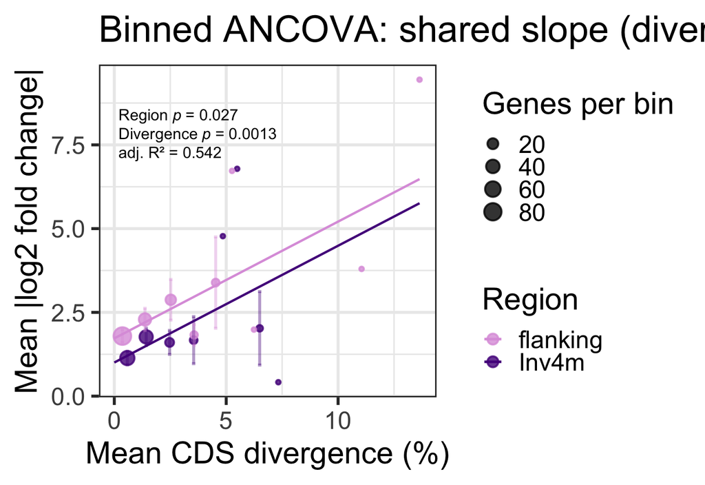

```r
# Predicted lines from additive model
pred_grid <- expand.grid(
  mean_div = seq(0, max(bin_means_loc$mean_div, na.rm = TRUE), length.out = 100),
  location = c("flanking", "Inv4m")
)
pred_grid$mean_absFC <- predict(fit_bin_loc, newdata = pred_grid)

# Stats for annotation (from binned ANCOVA)
bin_sum <- summary(fit_bin_loc)
bin_coefs <- coef(bin_sum)
bin_r2 <- round(bin_sum$adj.r.squared, 3)
bin_p_div <- bin_coefs["mean_div", "Pr(>|t|)"]
bin_p_loc <- bin_coefs["locationInv4m", "Pr(>|t|)"]

bin_stat_label <- paste0(
  "Region *p* = ", format(bin_p_loc, digits = 2), "<br>",
  "Divergence *p* = ", format(bin_p_div, digits = 2), "<br>",
  "adj. R\u00B2 = ", bin_r2
)

p_ancova <- ggplot(bin_means_loc, aes(x = mean_div, y = mean_absFC,
                                       color = location)) +
  geom_point(aes(size = n), alpha = 0.8) +
  geom_errorbar(aes(ymin = mean_absFC - se_absFC,
                    ymax = mean_absFC + se_absFC),
                width = 0.15, alpha = 0.4) +
  geom_line(data = pred_grid, linewidth = 0.9) +
  geom_richtext(
    data = data.frame(x = 0, y = 8.7),
    aes(x = x, y = y), label = bin_stat_label,
    inherit.aes = FALSE, hjust = 0, vjust = 1,
    size = 4.5, label.colour = NA, fill = NA
  ) +
  scale_color_manual(values = c("Inv4m" = "purple4", "flanking" = "plum"),
                     name = "Region") +
  scale_size_continuous(name = "Genes per bin") +
  labs(
    x = "Mean CDS divergence (%)",
    y = "Mean |log2 fold change|",
    title = "Binned ANCOVA: shared slope (divergence), offset = location"
  ) +
  theme_bw(base_size = 25)

print(p_ancova)
```

## Outlier genes (excess DE beyond divergence)

Genes with large positive residuals have more expression change than expected from their sequence divergence alone — candidates for trans-regulation or CNV effects.

```r
outliers <- merged %>%
  arrange(desc(abs(residual))) %>%
  dplyr::select(gene, location, pct_identity, cds_divergence,
                logFC, abs_logFC, adj.P.Val, residual) %>%
  head(20)

outliers
```

| gene | location | pct_identity | cds_divergence | logFC | abs_logFC | adj.P.Val | residual |
| --- | --- | --- | --- | --- | --- | --- | --- |
| Zm00001eb187280 | flanking | 99.30 | 0.70 | 10.022998 | 10.022998 | 2.401770e-10 | 8.044765 |
| Zm00001eb193620 | Inv4m | 99.20 | 0.80 | -8.604639 | 8.604639 | 9.015139e-12 | 7.310319 |
| Zm00001eb186400 | flanking | 100.00 | 0.00 | 7.786753 | 7.786753 | 2.150528e-05 | 6.041431 |
| Zm00001eb190240 | flanking | 95.51 | 4.49 | -9.098106 | 9.098106 | 2.249688e-14 | 5.858827 |
| Zm00001eb196760 | flanking | 97.58 | 2.42 | -8.316799 | 8.316799 | 3.457956e-14 | 5.766270 |
| Zm00001eb187430 | flanking | 98.40 | 1.60 | -7.948510 | 7.948510 | 6.246070e-08 | 5.670820 |
| Zm00001eb190090 | flanking | 97.88 | 2.12 | 7.230863 | 7.230863 | 1.055048e-06 | 4.780154 |
| Zm00001eb192970 | Inv4m | 98.39 | 1.61 | -6.159232 | 6.159232 | 6.151247e-09 | 4.595401 |
| Zm00001eb188750 | flanking | 99.28 | 0.72 | -6.416243 | 6.416243 | 5.199704e-14 | 4.431355 |
| Zm00001eb193260 | Inv4m | 98.61 | 1.39 | -5.878655 | 5.878655 | 2.869054e-13 | 4.388025 |

[output cut: 10 more lines]

## Distribution of divergence by region

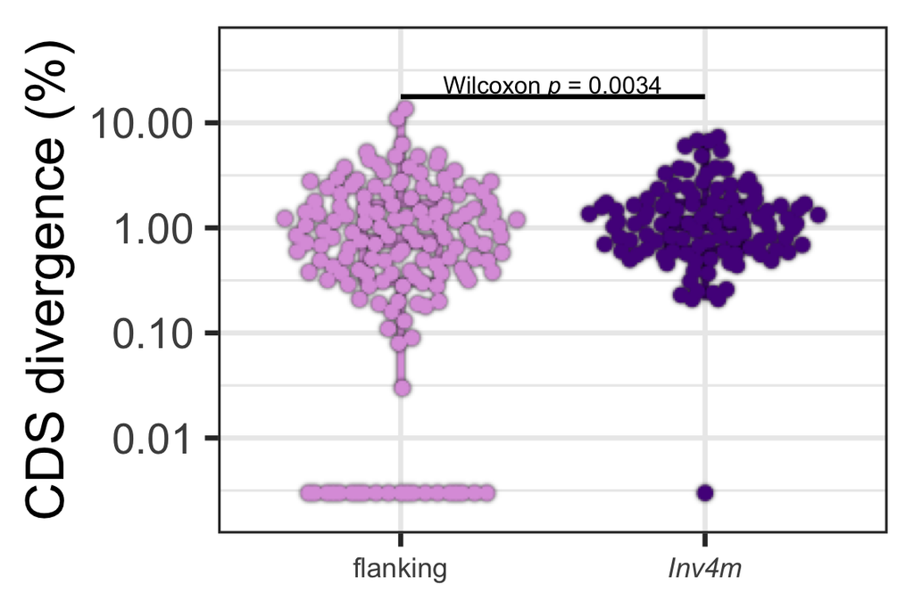

```r
# Pseudocount for zeros: one log10 unit below the minimum nonzero value
min_nz <- min(merged$cds_divergence[merged$cds_divergence > 0])
pseudo_zero <- min_nz / 10

merged_div_plot <- merged %>%
  mutate(div_plot = ifelse(cds_divergence == 0, pseudo_zero, cds_divergence))

# Wilcoxon test for annotation
wt <- wilcox.test(cds_divergence ~ location, data = merged)

p_beeswarm <- ggplot(merged_div_plot, aes(x = location, y = div_plot, color = location)) +
  geom_boxplot(width = 0.25, linewidth = 1.5, alpha = 0, outlier.shape = NA) %>%
    with_shadow(colour = "black", x_offset = 0, y_offset = 0, sigma = 1) +
  geom_quasirandom(size = 2) %>%
    with_shadow(colour = "black", x_offset = 0, y_offset = 0, sigma = 1) +
  scale_color_manual(values = c("Inv4m" = "purple4", "flanking" = "plum")) +
  scale_x_discrete(labels = c("Inv4m" = "*Inv4m*", "flanking" = "flanking")) +
  annotate("segment", x = 1, xend = 2, y = max(merged_div_plot$div_plot) * 1.3,
           yend = max(merged_div_plot$div_plot) * 1.3) +
  geom_richtext(
    data = data.frame(x = 1.5, y = max(merged_div_plot$div_plot) * 1.6),
    aes(x = x, y = y),
    label = paste0("Wilcoxon *p* = ", format(wt$p.value, digits = 2)),
    inherit.aes = FALSE, size = 4, label.colour = NA, fill = NA
  ) +
  scale_y_continuous(trans = "log10", expand = expansion(mult = c(0.1, 0.15))) +
  labs(x = NULL, y = "CDS divergence (%)") +
  theme_bw(base_size = 25) +
  theme(
    legend.position = "none",
    axis.text.x = element_markdown(size = 13)
  )

print(p_beeswarm)
```

```r
cat("=== Wilcoxon rank-sum test ===\n")
```

```
## === Wilcoxon rank-sum test ===
```

```r
print(wt)
```

```
##
##  Wilcoxon rank sum test with continuity correction
##
## data:  cds_divergence by location
## W = 6173, p-value = 0.003436
## alternative hypothesis: true location shift is not equal to 0
```

```r
cat("\n=== Welch t-test on log-transformed divergence ===\n")
```

```
##
## === Welch t-test on log-transformed divergence ===
```

```r
merged_div_plot$log_div <- log(merged_div_plot$div_plot)
print(t.test(log_div ~ location, data = merged_div_plot))
```

```
##
##  Welch Two Sample t-test
##
## data:  log_div by location
## t = -4.4951, df = 213.79, p-value = 1.139e-05
## alternative hypothesis: true difference in means between group flanking and group Inv4m is not equal to 0
## 95 percent confidence interval:
##  -1.3249481 -0.5171673
## sample estimates:
## mean in group flanking    mean in group Inv4m
##            -0.85514349             0.06591421
```

# Extreme value analysis

## Rationale

The approach:

1. Regress `logFC ~ cds_divergence` to remove the divergence effect
2. Take `|residual|` to pool both tails (comparable to the `abs_logFC` additive model)
3. Fit a Generalized Pareto Distribution (GPD) to the extreme |residuals|
4. Compare GPD parameters between Inv4m and flanking regions
5. If the scale or shape parameter differs, the inversion produces heavier tails (more extreme DE) than divergence alone predicts

## Residuals from divergence model

```r
# Robust residuals from divergence-only model, then take absolute value
# to pool both tails — directly comparable to the abs_logFC additive model
merged$robust_resid <- merged$logFC - predict(
  rlm(logFC ~ cds_divergence, data = merged),
  newdata = merged
)
merged$abs_resid <- abs(merged$robust_resid)

cat("Absolute residual summary:\n")
```

```
## Absolute residual summary:
```

```r
summary(merged$abs_resid)
```

```
##     Min.  1st Qu.   Median     Mean  3rd Qu.     Max.
##  0.03874  0.56026  1.24215  1.86948  2.49406 10.08529
```

## GPD threshold selection

```r
# Use 75th percentile of |residual| as threshold
thresh <- quantile(merged$abs_resid, 0.75)

cat("Threshold (75th pct of |residual|):", round(thresh, 3), "\n")
```

```
## Threshold (75th pct of |residual|): 2.494
```

```r
cat("Total exceedances:", sum(merged$abs_resid > thresh), "\n")
```

```
## Total exceedances: 64
```

```r
cat("  Inv4m:", sum(merged$abs_resid[merged$location == "Inv4m"] > thresh), "\n")
```

```
##   Inv4m: 20
```

```r
cat("  flanking:", sum(merged$abs_resid[merged$location == "flanking"] > thresh), "\n")
```

```
##   flanking: 44
```

## GPD fits by location (pooled tails)

```r
gpd_results <- list()

for (loc in c("Inv4m", "flanking")) {
  d <- merged %>% filter(location == loc)
  exc <- d$abs_resid[d$abs_resid > thresh]

  if (length(exc) >= 5) {
    fit <- fpot(d$abs_resid, threshold = thresh, model = "gpd")
    gpd_results[[loc]] <- list(
      location = loc,
      n_exceed = length(exc),
      scale = fit$estimate["scale"],
      shape = fit$estimate["shape"],
      se_scale = fit$std.err["scale"],
      se_shape = fit$std.err["shape"],
      nllh = fit$deviance  # negative log-likelihood
    )
    cat("===", loc, "===\n")
    cat("  Exceedances:", length(exc), "\n")
    cat("  Scale:", round(fit$estimate["scale"], 4),
        "±", round(fit$std.err["scale"], 4), "\n")
    cat("  Shape:", round(fit$estimate["shape"], 4),
        "±", round(fit$std.err["shape"], 4), "\n\n")
  }
}
```

```
## === Inv4m ===
##   Exceedances: 20
##   Scale: 1.5864 ± 0.5794
##   Shape: -0.0331 ± 0.2889
##
## === flanking ===
##   Exceedances: 44
##   Scale: 2.8992 ± 0.5709
##   Shape: -0.3001 ± 0.1345
```

```r
gpd_df <- bind_rows(lapply(gpd_results, as.data.frame))
gpd_df
```

|  | location | n_exceed | scale | shape | se_scale | se_shape | nllh |
| --- | --- | --- | --- | --- | --- | --- | --- |
| scale...1 | Inv4m | 20 | 1.586445 | -0.03312289 | 0.5794178 | 0.2888724 | 57.13486 |
| scale...2 | flanking | 44 | 2.899150 | -0.30011617 | 0.5709169 | 0.1344856 | 155.23759 |

## Compare tail behavior

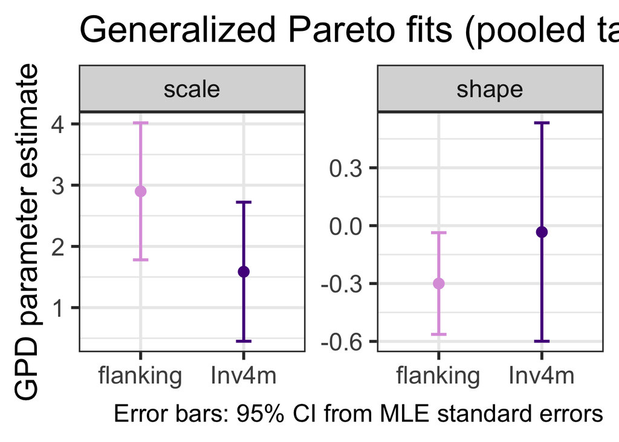

```r
gpd_long <- gpd_df %>%
  pivot_longer(cols = c(scale, shape), names_to = "parameter", values_to = "estimate") %>%
  mutate(se = ifelse(parameter == "scale", se_scale, se_shape))

ggplot(gpd_long, aes(x = location, y = estimate, color = location)) +
  geom_point(size = 3) +
  geom_errorbar(aes(ymin = estimate - 1.96 * se, ymax = estimate + 1.96 * se),
                width = 0.15) +
  facet_wrap(~ parameter, scales = "free_y") +
  scale_color_manual(values = c("Inv4m" = "purple4", "flanking" = "plum")) +
  labs(
    x = NULL, y = "GPD parameter estimate",
    title = "Generalized Pareto fits (pooled tails): |residual| by region",
    caption = "Error bars: 95% CI from MLE standard errors"
  ) +
  theme_bw(base_size = 25) +
  theme(legend.position = "none")
```

## Likelihood ratio test

Compare a model where both regions share GPD parameters vs separate fits.

```r
# Pooled fit (all locations combined)
fit_pooled <- fpot(merged$abs_resid, threshold = thresh, model = "gpd")

# Sum of separate negative log-likelihoods
nllh_separate <- sum(sapply(gpd_results, function(x) x$nllh))
nllh_pooled <- fit_pooled$deviance

# LRT: 2 * (loglik_separate - loglik_pooled), df = 2 (extra scale + shape)
lrt_stat <- 2 * (nllh_pooled - nllh_separate)
lrt_pval <- pchisq(lrt_stat, df = 2, lower.tail = FALSE)

cat("=== Likelihood ratio test: shared vs separate GPD ===\n")
```

```
## === Likelihood ratio test: shared vs separate GPD ===
```

```r
cat("  Pooled nllh:", round(nllh_pooled, 2), "\n")
```

```
##   Pooled nllh: 215.01
```

```r
cat("  Separate nllh:", round(nllh_separate, 2), "\n")
```

```
##   Separate nllh: 212.37
```

```r
cat("  LRT statistic:", round(lrt_stat, 3), "\n")
```

```
##   LRT statistic: 5.283
```

```r
cat("  p-value:", format(lrt_pval, digits = 4), "\n")
```

```
##   p-value: 0.07127
```

## Exceedance probability by location

```r
exc_table <- merged %>%
  group_by(location) %>%
  summarise(
    n = n(),
    n_extreme = sum(abs_resid > thresh),
    pct_extreme = round(100 * n_extreme / n, 1),
    .groups = "drop"
  )

exc_table
```

| location | n | n_extreme | pct_extreme |
| --- | --- | --- | --- |
| Inv4m | 107 | 20 | 18.7 |
| flanking | 147 | 44 | 29.9 |

```r
cat("\n=== Fisher's test: exceedance rate by location ===\n")
```

```
##
## === Fisher's test: exceedance rate by location ===
```

```r
mat <- matrix(c(
  exc_table$n_extreme[exc_table$location == "Inv4m"],
  exc_table$n[exc_table$location == "Inv4m"] - exc_table$n_extreme[exc_table$location == "Inv4m"],
  exc_table$n_extreme[exc_table$location == "flanking"],
  exc_table$n[exc_table$location == "flanking"] - exc_table$n_extreme[exc_table$location == "flanking"]
), nrow = 2, dimnames = list(c("extreme", "not"), c("Inv4m", "flanking")))
print(fisher.test(mat))
```

```
##
##  Fisher's Exact Test for Count Data
##
## data:  mat
## p-value = 0.05657
## alternative hypothesis: true odds ratio is not equal to 1
## 95 percent confidence interval:
##  0.2789642 1.0162047
## sample estimates:
## odds ratio
##  0.5394315
```

## QQ plots

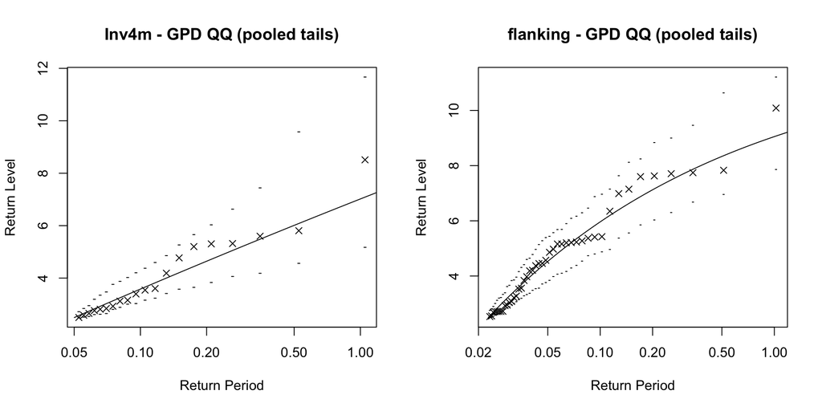

```r
par(mfrow = c(1, 2))

for (loc in c("Inv4m", "flanking")) {
  d <- merged %>% filter(location == loc)
  if (sum(d$abs_resid > thresh) >= 5) {
    fit <- fpot(d$abs_resid, threshold = thresh, model = "gpd")
    plot(fit, which = 4, main = paste(loc, "- GPD QQ (pooled tails)"))
  }
}
```

# Save outputs

```r
write.csv(merged, file.path(paths$intermediate, "sequence_divergence_vs_DE.csv"),
          row.names = FALSE)

ggsave(file.path(paths$figures, "sequence_divergence_vs_DE.pdf"),
       p_scatter, width = 8, height = 6)
ggsave(file.path(paths$figures, "sequence_divergence_vs_DE.svg"),
       p_scatter, width = 8, height = 6, fix_text_size = TRUE)

cat("Outputs saved to:", paths$intermediate, "and", paths$figures, "\n")
```

```
## Outputs saved to: /Users/fvrodriguez/Library/CloudStorage/GoogleDrive-frodrig4@ncsu.edu/My Drive/repos/inv4m/results/inversion_paper/intermediate and /Users/fvrodriguez/Library/CloudStorage/GoogleDrive-frodrig4@ncsu.edu/My Drive/repos/inv4m/results/inversion_paper/figures
```

## Multipanel figure

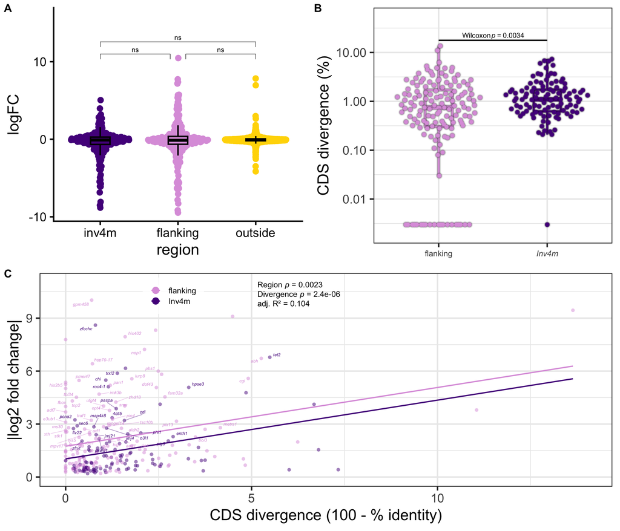

```r
library(cowplot)

# Load logFC by region panel from compare_r2_sliding_window_regions.Rmd
p_logfc_region <- readRDS(file.path(paths$intermediate, "panel_logfc_by_region.rds"))

# Remove titles from plots for the assembled figure
p_scatter_notitle <- p_scatter + labs(title = NULL)
p_beeswarm_notitle <- p_beeswarm + labs(title = NULL)

# Top row: (A) logFC by region | (B) CDS divergence beeswarm
top_row <- plot_grid(
  p_logfc_region + labs(title = NULL),
  p_beeswarm_notitle,
  nrow = 1,
  rel_widths = c(0.5, 0.5),
  labels = c("A", "B"),
  label_size = 18
)

# Bottom row: (C) |logFC| vs CDS divergence scatter (full width)
bottom_row <- plot_grid(
  p_scatter_notitle,
  nrow = 1,
  labels = c("C"),
  label_size = 18
)

# Stack rows
p_combined <- plot_grid(
  top_row,
  bottom_row,
  nrow = 2,
  rel_heights = c(1, 1)
)

print(p_combined)
```

```r
ggsave(file.path(paths$figures, "divergence.pdf"),
       p_combined, width = 14, height = 12)
ggsave(file.path(paths$figures, "divergence.png"),
       p_combined, width = 14, height = 12, dpi = 300)
ggsave(file.path(paths$figures, "divergence.svg"),
       p_combined, width = 14, height = 12, fix_text_size = TRUE)
```

# Zero-divergence DEGs and flanking enrichment

```r
# Genes with 0% CDS divergence
n_zero_inv4m <- sum(merged$cds_divergence == 0 & merged$location == "Inv4m")
n_zero_flank <- sum(merged$cds_divergence == 0 & merged$location == "flanking")
n_nonzero_inv4m <- sum(merged$cds_divergence > 0 & merged$location == "Inv4m")
n_nonzero_flank <- sum(merged$cds_divergence > 0 & merged$location == "flanking")

mat_zero <- matrix(
  c(n_zero_inv4m, n_nonzero_inv4m,
    n_zero_flank, n_nonzero_flank),
  nrow = 2,
  dimnames = list(c("zero_div", "nonzero_div"), c("Inv4m", "flanking"))
)

cat("Contingency table:\n")
```

```
## Contingency table:
```

```r
print(mat_zero)
```

```
##             Inv4m flanking
## zero_div        1       20
## nonzero_div   106      127
```

```r
ft_zero <- fisher.test(mat_zero)
cat("\nFisher's exact test: zero-divergence genes by location\n")
```

```
##
## Fisher's exact test: zero-divergence genes by location
```

```r
print(ft_zero)
```

```
##
##  Fisher's Exact Test for Count Data
##
## data:  mat_zero
## p-value = 0.0001254
## alternative hypothesis: true odds ratio is not equal to 1
## 95 percent confidence interval:
##  0.001436621 0.389721861
## sample estimates:
## odds ratio
## 0.06031275
```

```r
cat("\nAll", n_zero_inv4m + n_zero_flank, "zero-divergence genes are DEGs (FDR < 0.05)\n")
```

```
##
## All 21 zero-divergence genes are DEGs (FDR < 0.05)
```

```r
cat("  Inv4m:", n_zero_inv4m, "\n")
```

```
##   Inv4m: 1
```

```r
cat("  flanking:", n_zero_flank, "\n")
```

```
##   flanking: 20
```

# Results paragraph and figure caption

[output not shown]

[output not shown]

```
MODEL COMPARISON TABLE

\begin{table}[!ht]
\caption{\textbf{Model comparison for the relationship between CDS divergence and expression change in the \invfour introgression.}
Five linear models predicting $|\text{log}_2\text{FC}|$ were compared by BIC and AIC.
The additive model (CDS divergence + region) provided the best fit, with the interaction term adding no improvement.
Region distinguishes genes inside \invfour from the flanking introgression.}
\label{tab::divergence_models}
\centering
\begin{tabular}{@{}lcccc@{}}
\toprule
\textbf{Model} & \textbf{df} & \textbf{AIC} & \textbf{BIC} & \textbf{adj.\ $R^2$} \\ \midrule
CDS divergence + region & 3 & 1032.2 & 1046.3 & 0.1037 \\
CDS divergence & 2 & 1039.6 & 1050.2 & 0.0734 \\
CDS divergence $\times$ region & 4 & 1033.2 & 1050.9 & 0.1035 \\
Region & 2 & 1052.8 & 1063.4 & 0.0242 \\
Null (intercept only) & 1 & 1058 & 1065.1 & 0 \\ \bottomrule
\end{tabular}
\end{table}
```